# Family Planning.

## 3 Supplies and commodities

Commodity availability mirrors service availability, indicating that some service gaps are directly linked to commodity readiness. Male condoms and implants are available in 12 facilities, while oral combined contraceptives and oral progestin-only methods are more available in Ukerewe than Buchosa. Non-hormonal IUCD commodities are present in one facility in each council. Female condoms are absent in Buchosa and available in two Ukerewe facilities. Male sterilization kits are available in one Ukerewe facility and absent in Buchosa. Emergency pills and cycle beads are more available in Ukerewe. These findings suggest inequitable commodity distribution and limitations in method choice, continuity and contraceptive decision-making.

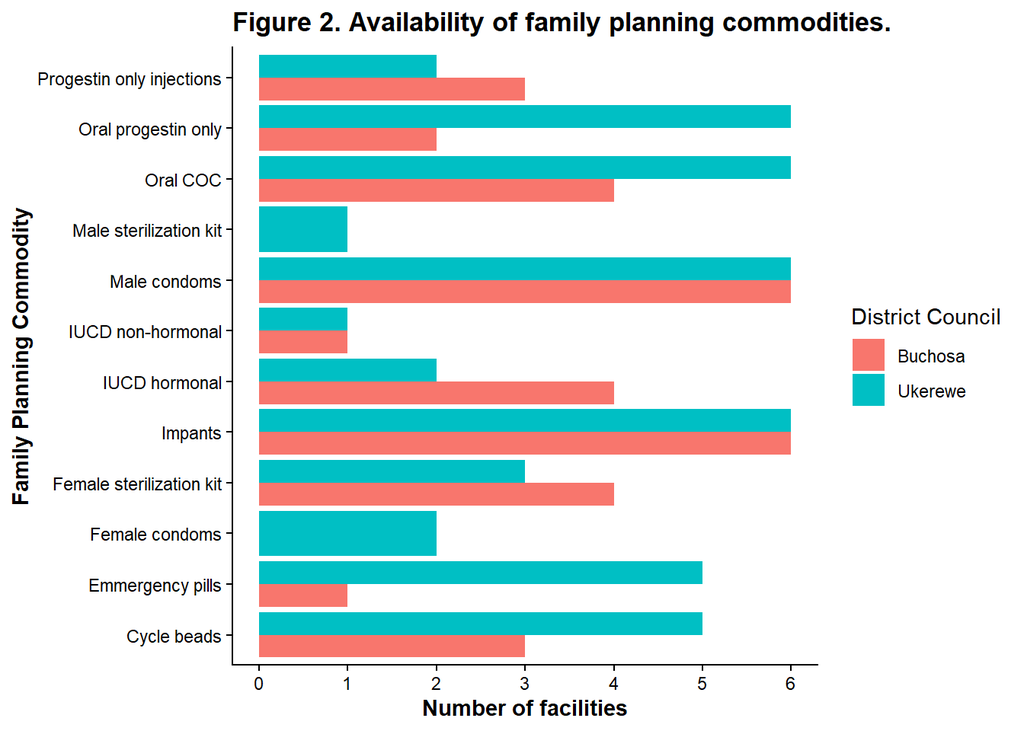

## 4 Equipment

### 4.1 Availability

Essential equipment availability presents a significant readiness constraint. Examination beds are relatively well covered, observed in 92% of facilities, while sponge-holding forceps and gallipots/kidney dishes are available in 75%. Tenaculum forceps, speculums, curved scissors, body scales and height boards are available in 67% of facilities. Uterine sounds and blood-pressure machines are available in 58%, while scalpels and examination lamps are present in half of facilities. Thermometers have the lowest availability at 42%. These gaps are important for IUD insertion, client assessment, infection prevention and safe service delivery. Equipment shortages therefore remain a practical barrier to comprehensive family planning readiness.

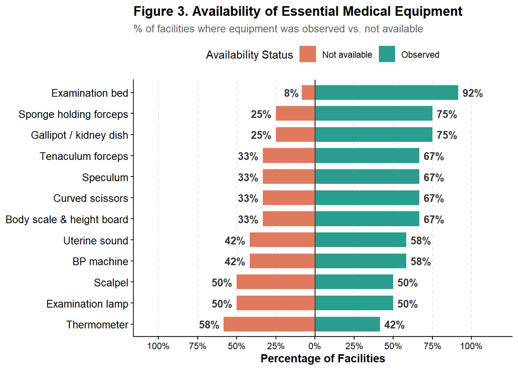

### 4.2 Functionality

Functionality among available equipment was strong, suggesting that the main challenge is procurement or distribution rather than widespread equipment failure. Uterine sounds, thermometers, tenaculum forceps, sponge-holding forceps, speculums, gallipots/kidney dishes, examination beds, curved scissors and blood-pressure machines were 100% functional among assessed items. However, body scales and height boards were 88% functional, while examination lamps were only 67% functional. The distinction between availability and functionality is important: even when equipment works, it cannot support services if it is absent. Priority should therefore be given to closing availability gaps while maintaining maintenance systems. This highlights need for planned equipment maintenance.

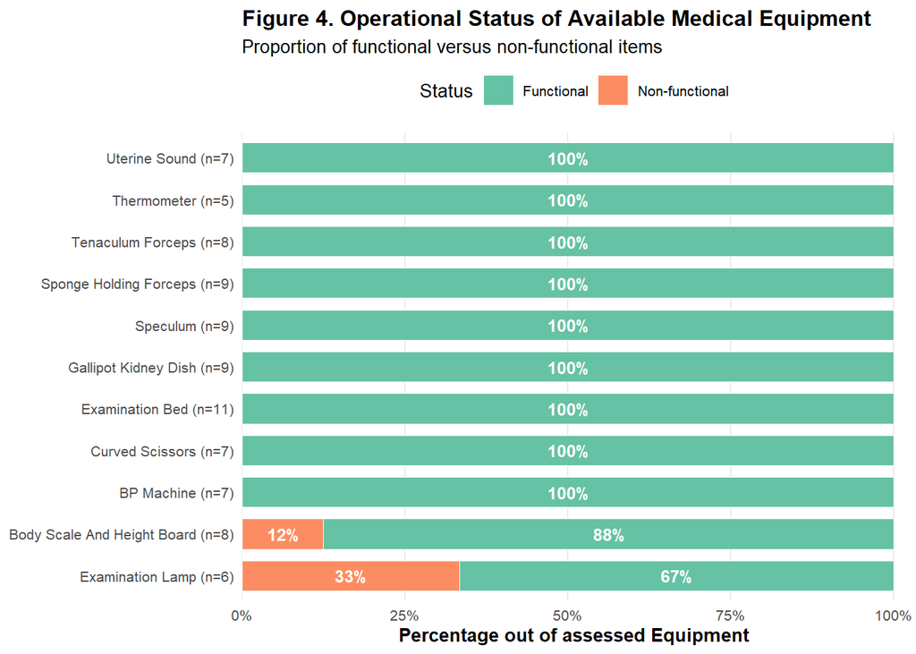

## 5 Guidelines and Medical Records

Documentation and guideline readiness is uneven. Client records/files are available in 92% of facilities and checklists/job aids in 67%, indicating stronger foundation for recording and supporting service delivery. However, the national family planning guideline is observed in 42% of facilities, while other family planning guidelines are available in 25%. Adolescent reproductive health guidance is particularly weak: both national and adolescent reproductive guidelines are observed in only 8% of facilities. This creates a risk that providers may deliver services without consistent access to standards, for adolescents and care. Guideline availability and use should therefore be strengthened alongside documentation quality.

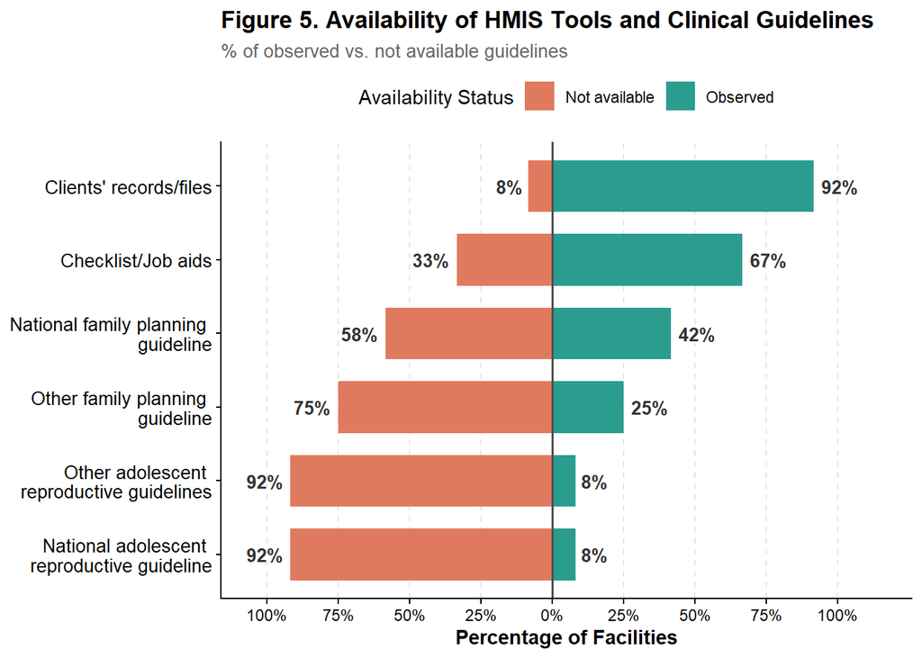

## 6 Family Planning Training

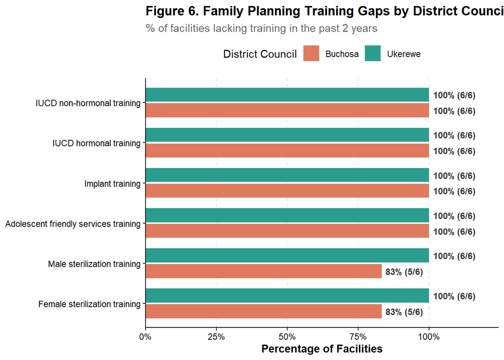

## 7 Discussion

Overall, the assessment demonstrates that family planning readiness is multidimensional and cannot be judged by service availability alone. Facilities may have commodities or functioning equipment while lacking the full package required for safe, informed and equitable care. Ukerewe generally shows broader availability for several services and commodities, whereas Buchosa has gaps. Across both councils, IUD services, permanent methods, adolescent-friendly care, guidelines and provider training require attention. The contrast between high functionality of available equipment and low equipment availability suggests supply and distribution weaknesses. Strengthening readiness should therefore combine commodity and equipment systems with clinical capacity, standards, documentation and supportive supervision.

## 8 Recommendations

The health system should prioritize a readiness improvement plan with clear responsibilities, timelines and monitoring indicators across the following strategic areas:

- Quantification and redistribution/procurement of family planning commodities and equipment, prioritizing IUCDs supplies, sterilization kits, examination lamps, thermometers, uterine sounds and blood-pressure machines.
- Competency-based training and mentorship for IUCDs insertion, implants, permanent methods and adolescent-friendly services.
- Ensure every facility has current national family planning and adolescent reproductive health guidelines, checklists and job aids.
- Strengthen stock monitoring, equipment maintenance and supportive supervision.
- Review progress quarterly using readiness indicators and address gaps at facility level through R/CHMT supervisions.

## 9 Conclusion

The assessment shows that family planning readiness across the 12 facilities is partial. Core methods such as implants, male condoms and oral contraceptives are established, but access to IUCDs, permanent methods and female condoms remains limited. Commodity gaps correspond with service gaps, while equipment availability is weaker than equipment functionality. Documentation is stronger than access to clinical and adolescent guidelines, and training gaps are widespread. These findings point to health system constraints that require coordinated action rather than isolated interventions. Improving commodity security, equipment availability, provider competence, guideline access and supportive supervision will be critical to achieving equitable and quality family planning services